# Week 3 Data Blitz. Sampling Error

Seongmin Park and Gareth Yu

October 16, 2026

# Loading Packages

```r
library(psych)
```

# Reading the Data

```r
filepath <- "https://raw.githubusercontent.com/craigenders/psych250a/main/data/Cancer.csv"
blitz <- read.csv(filepath, stringsAsFactors = TRUE)
```

# 1. Standard Error of the Depression Mean

Your code:

```r
sd(blitz$Depression)/sqrt(nrow(blitz))
```

```
[1] 0.6614158
```

Whether your calculation agrees with the descriptive statistics output, what the standard error quantifies, what a sampling distribution is, and how the standard error relates to that distribution:

# 2. Central Limit Theorem Predictions

What the central limit theorem predicts about the shape, center, and spread of the sampling distribution, and what you predict you will observe:

The central limit theorem predicts that the shape of the sampling distribution of sample means will be normally distributed, being symmetric and having a center at 16, which is the population mean. It predicts that the spread of the distribution will be 0.66 (the population standard deviation divided by the square root of the sample size). We predict the same.

# 3. Audit of the Simulation Code

AI’s response:

```
High-level conceptual recipe

Specify the population and sampling conditions

The simulation begins by defining a theoretical population with a known mean (16) and standard deviation (11.44), along with a sample size of 299.
Statistical purpose: establish the "true" population values and the sample size so the simulation can study how accurately sample means estimate the population mean.

Create a reproducible audit sample

A single random sample of 299 observations is drawn from the population, and the random-number process is fixed so the same sample can be reproduced every time.
Statistical purpose: provide a concrete example of one sample that could be observed from the population and allow others to verify the results exactly.

Check the characteristics of one sample

The script calculates the sample's mean, standard deviation, skewness, and excess kurtosis.
Statistical purpose: confirm that an individual sample looks reasonably consistent with the assumed population and inspect its shape, center, and spread. This helps verify that the data-generating process is behaving as expected before running the large simulation.

Visualize the single sample

A histogram of the audit sample is produced, with summary statistics displayed in a legend.
Statistical purpose: provide a visual check of the distribution of observations in one sample and illustrate that any single sample contains random variation.

Generate a large number of repeated samples

The simulation repeatedly draws 100,000 independent samples of size 299 from the same population.
Statistical purpose: mimic the process of collecting the same study over and over under identical conditions.

Compute and store a sample mean from each sample

For every simulated sample, the mean is calculated and saved.
Statistical purpose: build the sampling distribution of the sample mean, which shows how sample means vary across repeated samples.

Construct the sampling distribution

The 100,000 sample means are displayed in a histogram using fixed axis limits and bin widths.
Statistical purpose: visualize the distribution of sample means and show how concentrated they are around the true population mean.

Summarize the sampling distribution numerically

The simulation reports:
```

[output cut: 19 more lines]

[output not shown]

Your explanation of the simulation’s goal and major steps:

The goal of the simulation is to repeated sample from a population with a given mean and standard deviation, compute sample means, and create a sampling distribution to find the standard error. First, you have to specify a population and sampling condition, which include a population mean, standard deviation, and sample size. Next, it checks and visualizes the characteristics of one sample. Then, it generates a large number of repeated samples, computing the sample mean for each sample, and creating a sampling distribution with histograms and reporting the statistics of the sampling distribution.

# 4. Running the Simulation

The simulation code is below. Run the chunk as it is written.

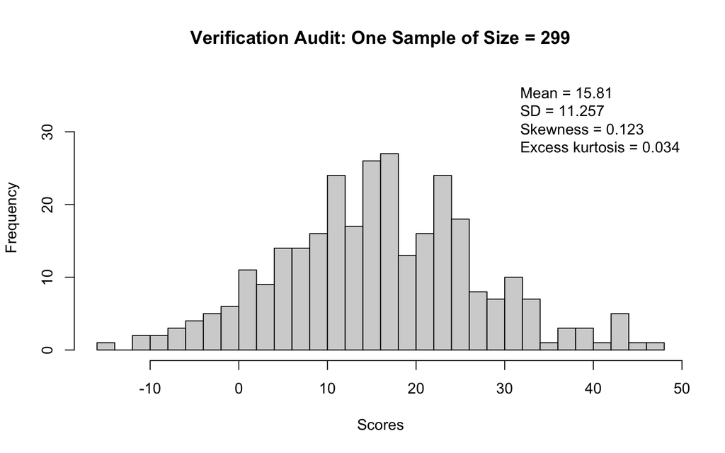

```r
# ---------------------------------------------------------------------
# SAMPLING ERROR SIMULATION
# ---------------------------------------------------------------------

# SIMULATION INPUTS ----

pop_mean <- 16        # population mean
pop_sd <- 11.44       # population standard deviation
sample_N <- 299       # sample size

# ---------------------------------------------------------------------
# SIMULATION CODE
# ---------------------------------------------------------------------

# VERIFICATION AUDIT ----

# makes the results identical every time the script is run
set.seed(250)

# draw a single sample of scores from the population
mysample <- rnorm(n = sample_N, mean = pop_mean, sd = pop_sd)

# mean, standard deviation, skewness, and excess kurtosis of the sample
audit_mean <- mean(mysample)
audit_sd <- sd(mysample)
audit_skew <- mean((mysample - audit_mean)^3) / audit_sd^3
audit_kurt <- mean((mysample - audit_mean)^4) / audit_sd^4 - 3

# tallest bar in the audit histogram, used to leave room for the legend
audit_barheight <- max(hist(mysample, breaks = 25, plot = FALSE)$counts)

# graph the sample
hist(mysample, breaks = 25,
     ylim = c(0, audit_barheight * 1.35),
     main = paste('Verification Audit: One Sample of Size =', sample_N),
     xlab = 'Scores')

legend('topright', bty = 'n',
       legend = c(paste('Mean =', round(audit_mean, 3)),
                  paste('SD =', round(audit_sd, 3)),
                  paste('Skewness =', round(audit_skew, 3)),
                  paste('Excess kurtosis =', round(audit_kurt, 3))))
```

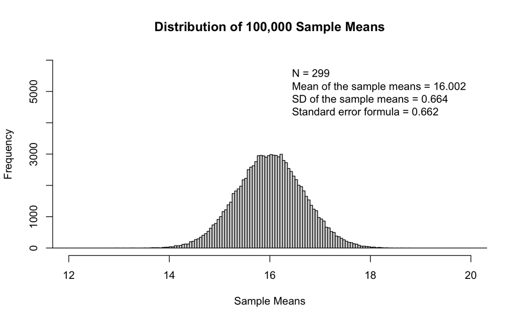

```r
# DRAW 100,000 RANDOM SAMPLES ----

# create an empty vector to hold the 100,000 sample means
samplemeans <- rep(0, 100000)

# draw a sample, compute its mean, and store the mean; repeat 100,000 times
for(s in 1:100000){
  sampledata <- rnorm(n = sample_N, mean = pop_mean, sd = pop_sd)
  samplemeans[s] <- mean(sampledata)
}

# EXAMINE THE SAMPLING DISTRIBUTION ----

# horizontal axis half-width
plot_halfwidth <- 4

# histogram bin width, also held constant so the bars are comparable
bin_width <- 0.05

# vertical axis maximum, held constant so bar heights are comparable
plot_maxcount <- 6000

# graph the 100,000 sample means with fixed bin width and axis ranges so graphs are comparable
hist(samplemeans,
     breaks = seq(pop_mean - 50, pop_mean + 50, by = bin_width),
     xlim = c(pop_mean - plot_halfwidth, pop_mean + plot_halfwidth),
     ylim = c(0, plot_maxcount),
     main = 'Distribution of 100,000 Sample Means',
     xlab = 'Sample Means')

legend(x = pop_mean + plot_halfwidth, y = plot_maxcount, xjust = 1, yjust = 1, bty = 'n',
       legend = c(paste('N =', sample_N),
                  paste('Mean of the sample means =', round(mean(samplemeans), 3)),
                  paste('SD of the sample means =', round(sd(samplemeans), 3)),
                  paste('Standard error formula =', round(pop_sd / sqrt(sample_N), 3))))
```

Whether the sampling distribution is consistent with your predictions from Question 2, and how the standard deviation of the 100,000 sample means compares with the standard error from Question 1:

The sampling distribution is normally distributed with a mean at 16.002 and a standard deviation of 0.664, which is consistent with our predictions based on the central limit theorem. The standard deviation from the sampling distribution is approximately the same as the standard error that we calculated in Question 1.

# 5. How Unusual Is a Sample Mean of 14.85?

# 6. Prediction and Simulation With a Different Population Mean

Your prediction about the center, shape, and spread with a population mean of 13:

We predict that the center of the sampling distribution will move to 13, but the shape and spread will remain unchanged.

The simulation code is below. The only change is the population mean.

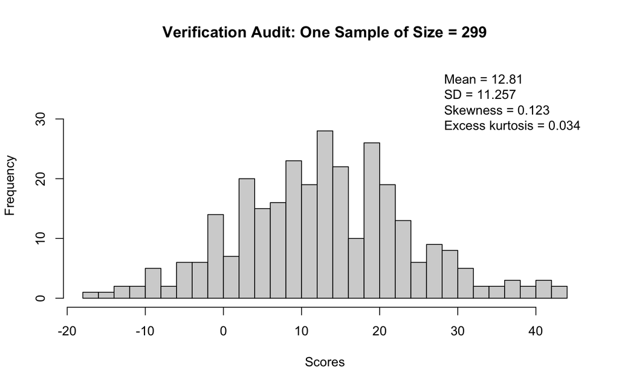

```r
# ---------------------------------------------------------------------
# SAMPLING ERROR SIMULATION
# ---------------------------------------------------------------------

# SIMULATION INPUTS ----

pop_mean <- 13        # population mean
pop_sd <- 11.44       # population standard deviation
sample_N <- 299       # sample size

# ---------------------------------------------------------------------
# SIMULATION CODE
# ---------------------------------------------------------------------

# VERIFICATION AUDIT ----

# makes the results identical every time the script is run
set.seed(250)

# draw a single sample of scores from the population
mysample <- rnorm(n = sample_N, mean = pop_mean, sd = pop_sd)

# mean, standard deviation, skewness, and excess kurtosis of the sample
audit_mean <- mean(mysample)
audit_sd <- sd(mysample)
audit_skew <- mean((mysample - audit_mean)^3) / audit_sd^3
audit_kurt <- mean((mysample - audit_mean)^4) / audit_sd^4 - 3

# tallest bar in the audit histogram, used to leave room for the legend
audit_barheight <- max(hist(mysample, breaks = 25, plot = FALSE)$counts)

# graph the sample
hist(mysample, breaks = 25,
     ylim = c(0, audit_barheight * 1.35),
     main = paste('Verification Audit: One Sample of Size =', sample_N),
     xlab = 'Scores')

legend('topright', bty = 'n',
       legend = c(paste('Mean =', round(audit_mean, 3)),
                  paste('SD =', round(audit_sd, 3)),
                  paste('Skewness =', round(audit_skew, 3)),
                  paste('Excess kurtosis =', round(audit_kurt, 3))))
```

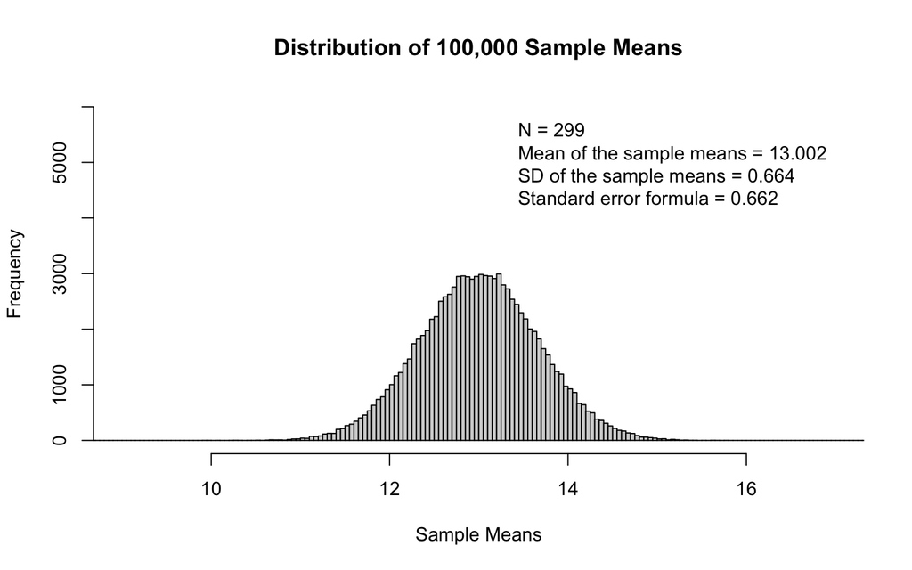

```r
# DRAW 100,000 RANDOM SAMPLES ----

# create an empty vector to hold the 100,000 sample means
samplemeans <- rep(0, 100000)

# draw a sample, compute its mean, and store the mean; repeat 100,000 times
for(s in 1:100000){
  sampledata <- rnorm(n = sample_N, mean = pop_mean, sd = pop_sd)
  samplemeans[s] <- mean(sampledata)
}

# EXAMINE THE SAMPLING DISTRIBUTION ----

# horizontal axis half-width
plot_halfwidth <- 4

# histogram bin width, also held constant so the bars are comparable
bin_width <- 0.05

# vertical axis maximum, held constant so bar heights are comparable
plot_maxcount <- 6000

# graph the 100,000 sample means with fixed bin width and axis ranges so graphs are comparable
hist(samplemeans,
     breaks = seq(pop_mean - 50, pop_mean + 50, by = bin_width),
     xlim = c(pop_mean - plot_halfwidth, pop_mean + plot_halfwidth),
     ylim = c(0, plot_maxcount),
     main = 'Distribution of 100,000 Sample Means',
     xlab = 'Sample Means')

legend(x = pop_mean + plot_halfwidth, y = plot_maxcount, xjust = 1, yjust = 1, bty = 'n',
       legend = c(paste('N =', sample_N),
                  paste('Mean of the sample means =', round(mean(samplemeans), 3)),
                  paste('SD of the sample means =', round(sd(samplemeans), 3)),
                  paste('Standard error formula =', round(pop_sd / sqrt(sample_N), 3))))
```

# 7. Why the Population Mean Does Not Matter

The sampling distributions from Questions 4 and 6 have the same shape and standard error. The only difference is that the center of the distribution from Question 4 is 16.002 and the center of the distribution from Question 6 is 13.002.

The population mean does not matter when the goal is to estimate the expected amount of sampling error across many samples because the standard error does not rely on the population mean. This is seen in the equation for standard error, which only includes population standard deviation and sample size.

# 8. Prediction for a Less Variable Population

What should happen to the shape, center, and spread of the sampling distribution when the population standard deviation is reduced from 11.44 to 6:

We predict that the center of the distribution will remain the same. The spread of the sampling distribution will be reduced, leading to a skinnier shape of the distribution and lower standard error.

# 9. AI on Variability and Sampling Error

Your prompt:

AI’s response:

[output not shown]

Whether AI’s response supports or contradicts your prediction from Question 8:

AI’s response supports our prediction from Question 8.

# 10. Simulation With a Smaller Population Standard Deviation

The simulation code is below. The only change is the population standard deviation.

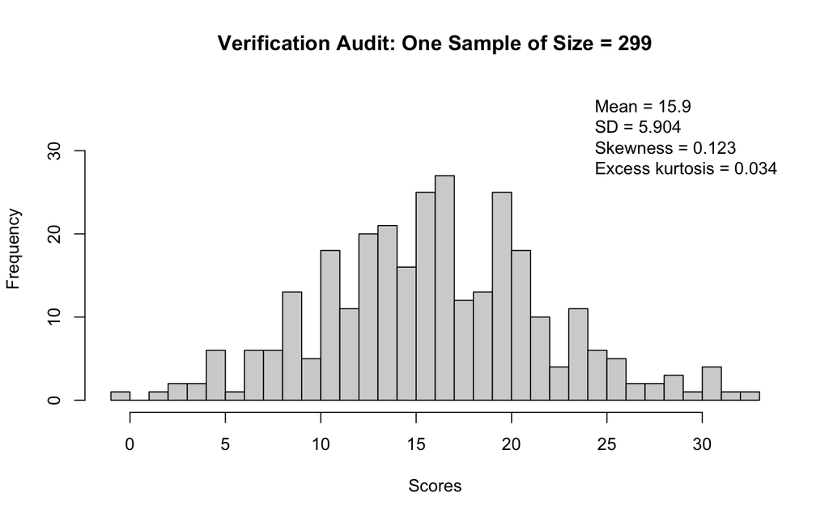

```r
# ---------------------------------------------------------------------
# SAMPLING ERROR SIMULATION
# ---------------------------------------------------------------------

# SIMULATION INPUTS ----

pop_mean <- 16        # population mean
pop_sd <- 6           # population standard deviation
sample_N <- 299       # sample size

# ---------------------------------------------------------------------
# SIMULATION CODE
# ---------------------------------------------------------------------

# VERIFICATION AUDIT ----

# makes the results identical every time the script is run
set.seed(250)

# draw a single sample of scores from the population
mysample <- rnorm(n = sample_N, mean = pop_mean, sd = pop_sd)

# mean, standard deviation, skewness, and excess kurtosis of the sample
audit_mean <- mean(mysample)
audit_sd <- sd(mysample)
audit_skew <- mean((mysample - audit_mean)^3) / audit_sd^3
audit_kurt <- mean((mysample - audit_mean)^4) / audit_sd^4 - 3

# tallest bar in the audit histogram, used to leave room for the legend
audit_barheight <- max(hist(mysample, breaks = 25, plot = FALSE)$counts)

# graph the sample
hist(mysample, breaks = 25,
     ylim = c(0, audit_barheight * 1.35),
     main = paste('Verification Audit: One Sample of Size =', sample_N),
     xlab = 'Scores')

legend('topright', bty = 'n',
       legend = c(paste('Mean =', round(audit_mean, 3)),
                  paste('SD =', round(audit_sd, 3)),
                  paste('Skewness =', round(audit_skew, 3)),
                  paste('Excess kurtosis =', round(audit_kurt, 3))))
```

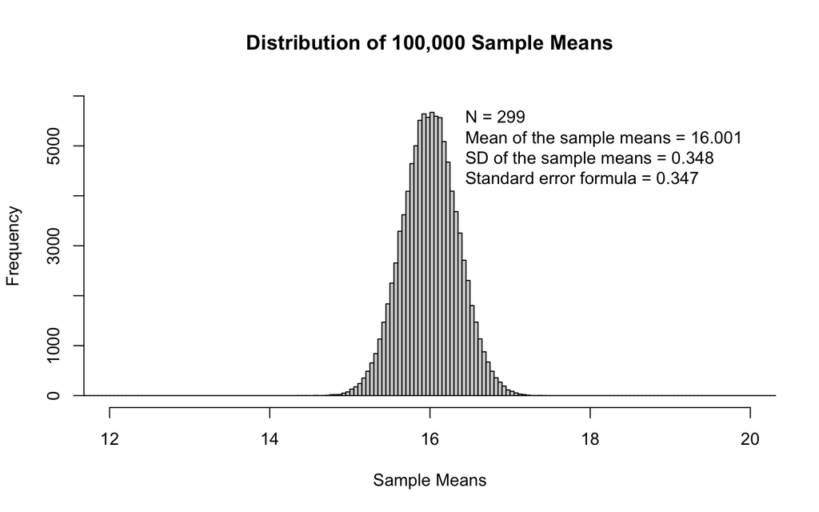

```r
# DRAW 100,000 RANDOM SAMPLES ----

# create an empty vector to hold the 100,000 sample means
samplemeans <- rep(0, 100000)

# draw a sample, compute its mean, and store the mean; repeat 100,000 times
for(s in 1:100000){
  sampledata <- rnorm(n = sample_N, mean = pop_mean, sd = pop_sd)
  samplemeans[s] <- mean(sampledata)
}

# EXAMINE THE SAMPLING DISTRIBUTION ----

# horizontal axis half-width
plot_halfwidth <- 4

# histogram bin width, also held constant so the bars are comparable
bin_width <- 0.05

# vertical axis maximum, held constant so bar heights are comparable
plot_maxcount <- 6000

# graph the 100,000 sample means with fixed bin width and axis ranges so graphs are comparable
hist(samplemeans,
     breaks = seq(pop_mean - 50, pop_mean + 50, by = bin_width),
     xlim = c(pop_mean - plot_halfwidth, pop_mean + plot_halfwidth),
     ylim = c(0, plot_maxcount),
     main = 'Distribution of 100,000 Sample Means',
     xlab = 'Sample Means')

legend(x = pop_mean + plot_halfwidth, y = plot_maxcount, xjust = 1, yjust = 1, bty = 'n',
       legend = c(paste('N =', sample_N),
                  paste('Mean of the sample means =', round(mean(samplemeans), 3)),
                  paste('SD of the sample means =', round(sd(samplemeans), 3)),
                  paste('Standard error formula =', round(pop_sd / sqrt(sample_N), 3))))
```

Your comparison with the distribution from Question 4, whether your predictions were correct, and whether the standard error formula agrees with the standard deviation of the 100,000 sample means:

The new sampling distribution has a skinnier shape and reduced sampling error compared to the original distribution from Question 4, but they have the same center at 16. Our predictons about the sample, center, and spread were correct. The calculated standard error of 0.347 agrees with the standard deviation of the sample means of 0.348.

# 11. Reflection on AI

We found AI useful for generating a high level conceptual description of the simulation process. We did not run into any issues while using AI.